# IS 4487 Lab 13

## Learning Objectives

1. Select appropriate variables for a cluster analysis
2. Learn to fit and adjust a cluster analysis model based on similar customer behavioural patterns.
3. Interpret the output of the model

## Lab Tasks

1. Import and prepare data using the *SuperStore Retail Orders* dataset
2. Convert categorical variables to numbers or boolean
3. Fit a K-means model with 5 clusters
4. Display and analyze the results

## Superstore Data Dictionary

ORDER VARIABLES:

- Order ID
- Order Date
- Order Year Month - Year and month of the order
- Order Type - Was the order completed at a store or online? (Retail, Online)
- Quantity - Quantity ordered for the product

CUSTOMER VARIABLES:

- Customer Name
- City
- State Province
- Email

PRODUCT VARIABLES:

- Product Name
- Product Line - Category of the product (i.e. Bikes Phones)
- Product Price - Price in US Dollars
- Product Status - Current status of the product (Active, Inactive)

## Load Libraries

➡️ Assignment Tasks

- Load any other necessary libraries, in addition to those below

```python
import pandas as pd
import numpy as np
from sklearn.preprocessing import OneHotEncoder
from sklearn.cluster import KMeans
import matplotlib.pyplot as plt
```

## Import Data into Dataframe

➡️ Assignment Tasks

- Import data from the SuperStore retail dataset into a dataframe (in GitHub go to Labs > DataSets)
- Describe or profile the dataframe

```python
df = pd.read_csv('https://raw.githubusercontent.com/Stan-Pugsley/is_4487_base/main/Labs/DataSets/superstore_retail_orders.csv')
print(df)
```

```
       order_id  order_date order_year_month     customer_name  \
0         51188  2023-07-01          2023-07     Audrey Blanco
1         51187  2023-07-01          2023-07       Isaac Allen
2         51199  2023-07-02          2023-07        Ian Morgan
3         51241  2023-07-04          2023-07        Alexa Bell
4         51297  2023-07-08          2023-07        Casey Diaz
...         ...         ...              ...               ...
56038     74084  2024-06-29          2024-06        Ian Rogers
56039     74062  2024-06-29          2024-06   Marcus Anderson
56040     74065  2024-06-29          2024-06  Nathaniel Howard
56041     74038  2024-06-29          2024-06        Robin Sanz
56042     74110  2024-06-30          2024-06   Mallory Jimenez

                    city state_province                       email  \
0      North Cherylmouth  New Hampshire     audrey_blanco@email.com
```

[output cut: 38 more lines]

```python
df.info()
```

```
<class 'pandas.core.frame.DataFrame'>
RangeIndex: 56043 entries, 0 to 56042
Data columns (total 13 columns):
 #   Column            Non-Null Count  Dtype
---  ------            --------------  -----
 0   order_id          56043 non-null  int64
 1   order_date        56011 non-null  object
 2   order_year_month  56011 non-null  object
 3   customer_name     56043 non-null  object
 4   city              55569 non-null  object
 5   state_province    55569 non-null  object
 6   email             56043 non-null  object
 7   order_type        56043 non-null  object
 8   quantity          56004 non-null  float64
 9   product_name      56043 non-null  object
 10  product_line      56043 non-null  object
 11  product_price     56043 non-null  float64
 12  product_status    56043 non-null  object
dtypes: float64(2), int64(1), object(10)
memory usage: 5.6+ MB
```

## Prepare Data

Note that K-Means requires that all variables be numbers or boolean. No categorical variables are allowed.

➡️ Assignment Tasks

- Copy your dataframe into a new version, so that the original data is still available
- Create any needed variables, such as month of year and total_amount.
- Filter out any incomplete orders
- Convert the OrderType and Product Line variables to multiple one-hot variables using OneHotEncoder (one variable for each value)
- Remove any variables that will be not be included (hint: only numeric variables are allowed)
- Remove any outliers that will cause a cluster to be created for the few records with the outlier value (pay close attention to dates, quantities and prices)

*Notes:*

- There is no need to split the data for cluster analysis. Why is that the case?
- You should think carefully about which variables to include. They should be independent and numeric, and have some behavioural aspect for customers. A date, for example, cannot be used unless it is somehow converted to a number.

```python
#create new dataframe and do any number conversion
df_cluster = df.copy()

# OrderDate to DateTime
df_cluster['order_date'] = pd.to_datetime(df_cluster['order_date'], errors='coerce')
# New variable Month extracted from order date
df_cluster['Month'] = df_cluster['order_date'].dt.month

# Create a Total Amount Variable
df_cluster['Total_Amount'] = df_cluster['quantity'] * df_cluster['product_price']
pd.set_option('display.float_format', '{:.2f}'.format)
```

```python
#filter records with incomplete or invalid data
required_columns = ['order_date', 'order_type', 'quantity', 'product_line', 'product_price']
df_cluster = df_cluster.dropna(subset=required_columns)
```

```python
cols_to_encode = ['order_type', 'product_line']

# Initialize the OneHotEncoder (using 'sparse_output=False' for scikit-learn versions 1.2+)
encoder = OneHotEncoder(sparse_output=False, drop=None)
encoded_array = encoder.fit_transform(df_cluster[cols_to_encode])
encoded_cols = encoder.get_feature_names_out(cols_to_encode)
df_encoded = pd.DataFrame(encoded_array, columns=encoded_cols, index=df_cluster.index)

# Remove the original columns and concatenate the new one-hot variables
df_cluster = pd.concat([df_cluster.drop(columns=cols_to_encode), df_encoded], axis=1)
```

```python
# only number variables
df_cluster = df_cluster.select_dtypes(include=[np.number])
```

```python
#remove outliers
def remove_outliers_iqr(df, col):
    Q1 = df[col].quantile(0.25)
    Q3 = df[col].quantile(0.75)
    IQR = Q3 - Q1
    lower_bound = Q1 - 1.5 * IQR
    upper_bound = Q3 + 1.5 * IQR
    return df[(df[col] >= lower_bound) & (df[col] <= upper_bound)]

# Remove outliers for each variable one at a time.
for col in ['quantity', 'product_price', 'Total_Amount']:
    df_cluster = remove_outliers_iqr(df_cluster, col)

# Reset index after cleaning
df_cluster = df_cluster.reset_index(drop=True)

print(df_cluster.head())
print(df_cluster.describe())
```

```
   order_id  quantity  product_price  Month  Total_Amount  order_type_Online  \
0     51241      1.00         649.99   7.00        649.99               1.00
1     51297      1.00         649.99   7.00        649.99               1.00
2     51319      1.00         649.99   7.00        649.99               1.00
3     51357      1.00         649.99   7.00        649.99               1.00
4     51371      1.00         649.99   7.00        649.99               1.00

   order_type_Retail  product_line_Accessories  product_line_Bikes  \
0               0.00                      0.00                0.00
1               0.00                      0.00                0.00
2               0.00                      0.00                0.00
3               0.00                      0.00                0.00
4               0.00                      0.00                0.00

   product_line_Cameras  product_line_Clothing  product_line_Electronics  \
0                  0.00                   0.00                      0.00
1                  0.00                   0.00                      0.00
2                  0.00                   0.00                      0.00
3                  0.00                   0.00                      0.00
4                  0.00                   0.00                      0.00

   product_line_Laptop  product_line_Mobile  product_line_OfficeProducts  \
0                 0.00                 1.00                         0.00
1                 0.00                 1.00                         0.00
2                 0.00                 1.00                         0.00
3                 0.00                 1.00                         0.00
4                 0.00                 1.00                         0.00

   product_line_Projector
0                    0.00
1                    0.00
2                    0.00
3                    0.00
4                    0.00
       order_id  quantity  product_price    Month  Total_Amount  \
count  46487.00  46487.00       46487.00 46487.00      46487.00
mean   62471.75      1.56         328.47     6.35        398.06
std     6874.58      0.61         405.00     3.55        502.80
min    45080.00      1.00           2.29     1.00          2.29
25%    56612.00      1.00           4.99     3.00          9.98
```

[output cut: 28 more lines]

```
min                        0.00                 0.00                 0.00
25%                        0.00                 0.00                 0.00
50%                        0.00                 0.00                 0.00
75%                        1.00                 0.00                 0.00
max                        1.00                 0.00                 1.00

       product_line_OfficeProducts  product_line_Projector
count                     46487.00                46487.00
mean                          0.04                    0.00
std                           0.21                    0.00
min                           0.00                    0.00
25%                           0.00                    0.00
50%                           0.00                    0.00
75%                           0.00                    0.00
max                           1.00                    0.00
```

```python
#eliminate any variables that you don't want to use in the model (select your final variable set)
final_columns = ['quantity', 'product_price', 'Total_Amount', 'Month'] \
              + [col for col in df_cluster.columns if col.startswith('order_type_')] \
              + [col for col in df_cluster.columns if col.startswith('product_line_')]

# Create the final dataset (a copy) using only the selected variables.
df_model = df_cluster[final_columns].copy()

# Optional: Check the final variable set
print(df_model.columns)
```

```
Index(['quantity', 'product_price', 'Total_Amount', 'Month',
       'order_type_Online', 'order_type_Retail', 'product_line_Accessories',
       'product_line_Bikes', 'product_line_Cameras', 'product_line_Clothing',
       'product_line_Electronics', 'product_line_Laptop',
       'product_line_Mobile', 'product_line_OfficeProducts',
       'product_line_Projector'],
      dtype='object')
```

## Create Model

For more info on K-means in python, see: https://realpython.com/k-means-clustering-python/

➡️ Assignment Tasks

- Fit the K-means model using the Kmeans method
- Use 5 clusters

```python
#create and fit model
from sklearn.preprocessing import StandardScaler

scaler = StandardScaler()
X_scaled = scaler.fit_transform(df_model)

# Create the KMeans model with 5 clusters
kmeans = KMeans(n_clusters=5, random_state=42)

# Fit the model on the scaled data
kmeans.fit(X_scaled)

# Add the resulting cluster labels back to the DataFrame
df_model['Cluster'] = kmeans.labels_
```

## Analyze the Clusters

➡️ Assignment Tasks

- create at least two visualizations to show the clusters (try a Bar Chart, Pair Plot or Scatter Plot)
- Display the cluster and mean values for each of the variables

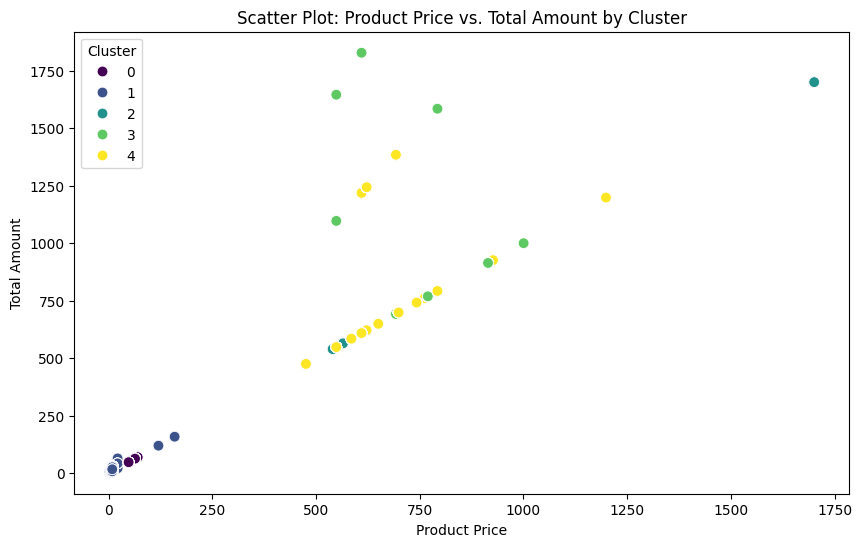

```python
#visualization #1: Scatter Plot
import seaborn as sns

plt.figure(figsize=(10, 6))
sns.scatterplot(
    data=df_model,
    x='product_price',
    y='Total_Amount',
    hue='Cluster',
    palette='viridis',  # you can change the palette as needed
    s=60               # marker size
)
plt.title("Scatter Plot: Product Price vs. Total Amount by Cluster")
plt.xlabel("Product Price")
plt.ylabel("Total Amount")
plt.legend(title='Cluster', loc='upper left')
plt.show()
```

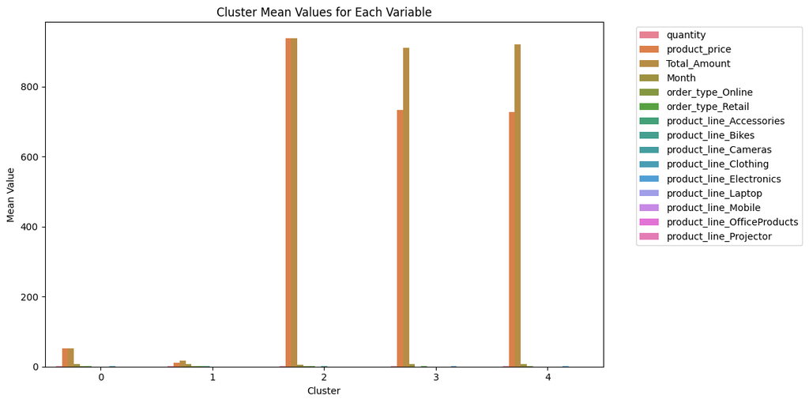

```python
#visualization #2: Bar Chart
cluster_means = df_model.groupby('Cluster').mean()

# Reset index and melt the DataFrame so that each variable's mean is a separate row.
cluster_means_reset = cluster_means.reset_index()
cluster_means_melted = cluster_means_reset.melt(id_vars='Cluster', var_name='Variable', value_name='Mean')

plt.figure(figsize=(12, 6))
sns.barplot(x='Cluster', y='Mean', hue='Variable', data=cluster_means_melted)
plt.title("Cluster Mean Values for Each Variable")
plt.xlabel("Cluster")
plt.ylabel("Mean Value")
plt.legend(bbox_to_anchor=(1.05, 1), loc='upper left')
plt.tight_layout()
plt.show()
```

```python
#cluster summary statistics
cluster_summary = df_model.groupby('Cluster').describe()

print("Cluster Summary Statistics:\n")
print(cluster_summary)
```

```
Cluster Summary Statistics:

        quantity                                    product_price         ...  \
           count mean  std  min  25%  50%  75%  max         count   mean  ...
Cluster                                                                   ...
0        5108.00 1.10 0.35 1.00 1.00 1.00 1.00 3.00       5108.00  51.31  ...
1       21925.00 1.94 0.54 1.00 2.00 2.00 2.00 3.00      21925.00  11.24  ...
2        2662.00 1.00 0.00 1.00 1.00 1.00 1.00 1.00       2662.00 937.19  ...
3        8752.00 1.27 0.47 1.00 1.00 1.00 2.00 3.00       8752.00 733.34  ...
4        8040.00 1.29 0.48 1.00 1.00 1.00 2.00 3.00       8040.00 727.37  ...

        product_line_OfficeProducts      product_line_Projector            \
                                75%  max                  count mean  std
Cluster
0                              0.00 0.00                5108.00 0.00 0.00
1                              0.00 1.00               21925.00 0.00 0.00
2                              0.00 0.00                2662.00 0.00 0.00
3                              0.00 0.00                8752.00 0.00 0.00
4                              0.00 0.00                8040.00 0.00 0.00


         min  25%  50%  75%  max
Cluster
0       0.00 0.00 0.00 0.00 0.00
1       0.00 0.00 0.00 0.00 0.00
2       0.00 0.00 0.00 0.00 0.00
3       0.00 0.00 0.00 0.00 0.00
4       0.00 0.00 0.00 0.00 0.00

[5 rows x 120 columns]
```